# DIMAS_FINAL

Drew Dimas

2023-02-22

# Introduction and Theory

The 2016 Presidential election was a truly divisive time for the country. The time during Donald Trump’s presidency was filled with riots, protests, and even an insurrection. Because of this, did peoples opinion on whether the USA was headed in the right or wrong direction effect their feeling on Biden in the 2020 election, regardless of their political party?

# Description of Main Variables

To investigate this relationship further, I used the American National Election Study, an academic study of the American adult population with a sample size of around 8000 individuals.

The main outcome variable I will be focused on is the “Feeling Thermometer” for now President Joe Biden. This question asks respondents how “warm” they feel towards Biden, where 0 means “cold” and 100 means “hot”. Individuals are instructed that 50 degrees means that “you don’t feel particularly warm or cold toward the person.” The mean of this variable, 49.24 makes it seem like Americans are ambivalent towards Joe Biden, but the standard deviation of 34.5 indicates that views are highly variable. This is due to the distribution of this variable which has been displayed below. There are many individuals who rate Biden very negatively, many as low as 0. On the other hand, there are also a large group of individual that feel warmly about him, with notable ratings spikes around 65-85.

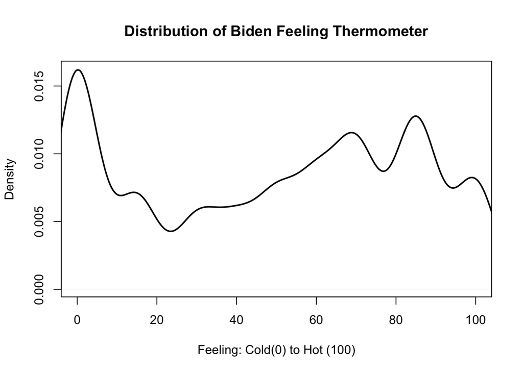

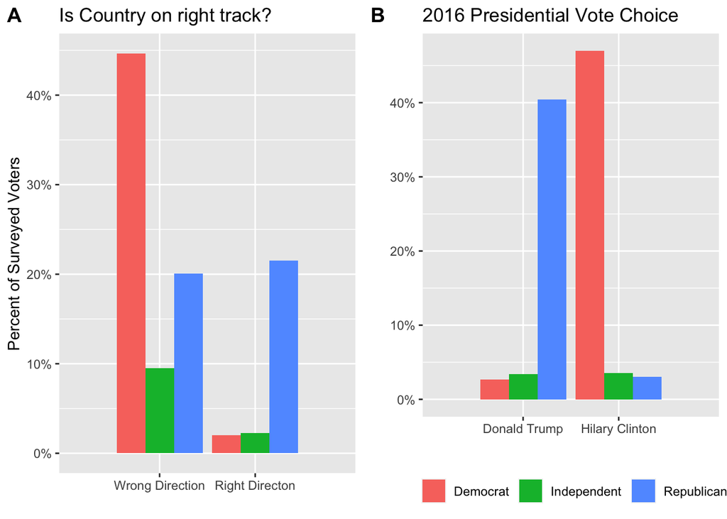

# Difference in Means

For republicans the differences in mean is -11.31956 . When looking at Democrats only, the difference in mean is -20.49513 . Both of these t-tests have results that allow us to reject the null hypothesis.

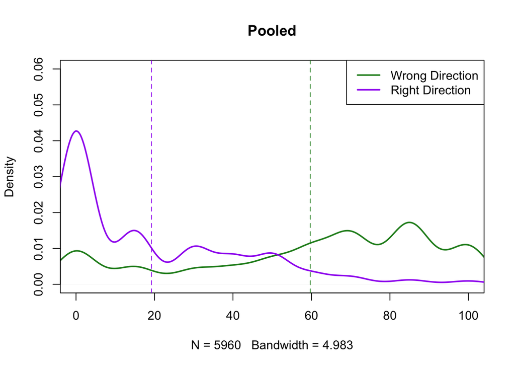

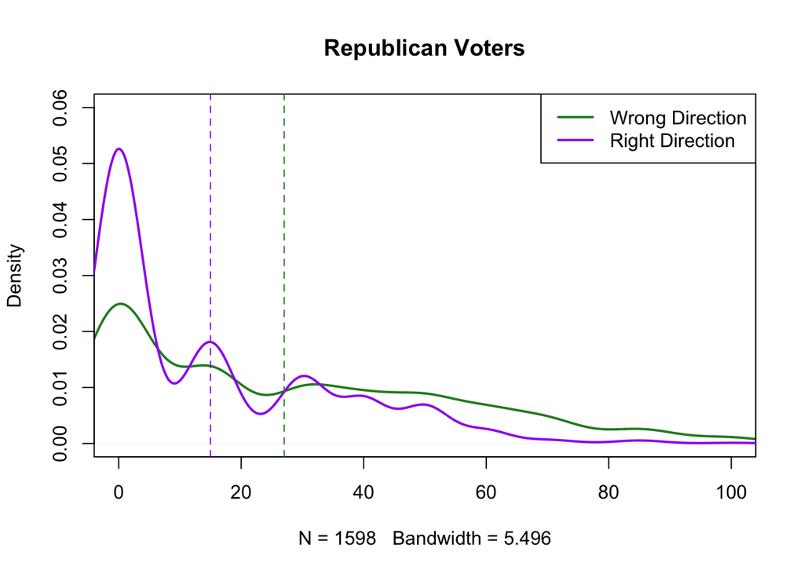

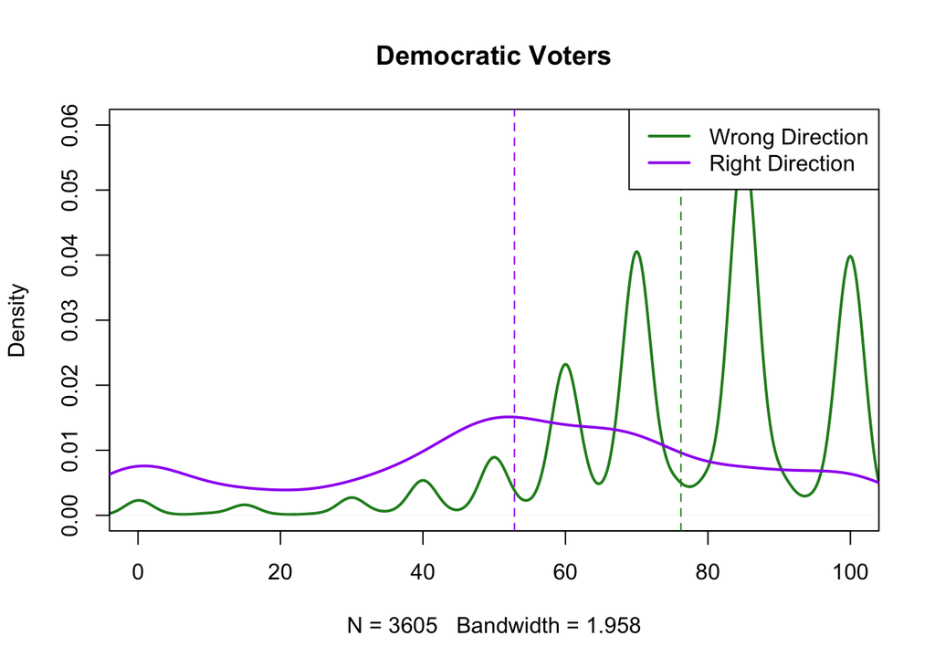

# Regression Analysis

```r
summary(lm(biden.ft ~ RD1WT0, data = anes, weights = weight))
```

```
##
## Call:
## lm(formula = biden.ft ~ RD1WT0, data = anes, weights = weight)
##
## Weighted Residuals:
##      Min       1Q   Median       3Q      Max
## -143.788  -16.459    2.095   19.405  191.422
##
## Coefficients:
##             Estimate Std. Error t value Pr(>|t|)
## (Intercept)  58.4101     0.3880  150.55   <2e-16 ***
## RD1WT0      -38.7997     0.7536  -51.48   <2e-16 ***
## ---
## Signif. codes:  0 '***' 0.001 '**' 0.01 '*' 0.05 '.' 0.1 ' ' 1
##
## Residual standard error: 29.83 on 8010 degrees of freedom
##   (268 observations deleted due to missingness)
## Multiple R-squared:  0.2486, Adjusted R-squared:  0.2485
## F-statistic:  2651 on 1 and 8010 DF,  p-value: < 2.2e-16
```

```r
summary(lm(biden.ft ~ RD1WT0 + parties + HC1DT0, data = anes, weights = weight))
```

```
##
## Call:
## lm(formula = biden.ft ~ RD1WT0 + parties + HC1DT0, data = anes,
##     weights = weight)
##
## Weighted Residuals:
##      Min       1Q   Median       3Q      Max
## -189.914  -10.666    1.714   10.593  100.358
##
## Coefficients:
##                    Estimate Std. Error t value Pr(>|t|)
## (Intercept)         51.7063     1.0376   49.83   <2e-16 ***
## RD1WT0              -8.4379     0.7158  -11.79   <2e-16 ***
## partiesIndependent -16.4243     1.1638  -14.11   <2e-16 ***
## partiesRepublican  -30.8781     1.0458  -29.53   <2e-16 ***
## HC1DT0              27.4804     1.0151   27.07   <2e-16 ***
## ---
## Signif. codes:  0 '***' 0.001 '**' 0.01 '*' 0.05 '.' 0.1 ' ' 1
##
## Residual standard error: 19.18 on 5757 degrees of freedom
##   (2518 observations deleted due to missingness)
## Multiple R-squared:  0.6946, Adjusted R-squared:  0.6944
## F-statistic:  3274 on 4 and 5757 DF,  p-value: < 2.2e-16
```

[output not shown]